# Exploring The Full Model

### Packages and Data

In this document we’re going to explore the full model and look at condition-specific contrasts. Of course, we’ll start by loading our packages.

```r
##load packages (all on CRAN; use install.packages() if first time)
library(brms) #Bayesian regressions with STAN
library(tidyverse) #Load dplyr, ggplot and others
library(tidybayes) #Useful functions for describing posterior (e.g., mean_hdi)
library(ggplot2) #Good-looking visualization package
library(bayesplot) #Quick and easy coef plots.
library(ggridges) #Fancy density ridgeplots for fancy people.
library(magrittr) #For two-way pipes
library(rstudioapi) #Allows RStudio to get the current working directory.
library(patchwork) #Easily stitch figures together with operators.
library(xtable) # Brings many types table format to the table. Used here to export LaTeX tables.
library(ggtext) #Use HTML Elements in GGPlot
```

Next let’s load the data. As before, this uses the rstudio API and requires that the appropriate .rda file be in the same folder as this script.

```r
setwd(dirname(getActiveDocumentContext()$path))
load("carnivaldata.rda")
load("carnivalfullmodel.rda")
```

In case there are any sources of (psuedo-)random variation in our functions, let’s set a RNG seed.

```r
set.seed(42)
```

Now we can start exploring the full model.

## Exploring the Full Model

First, we’ll wrangle our data and convert to the probability scale in order to reproduce our fitted outputs. It’s a complex model and the corresponding code is also complex.

```r
ps_CrGtrSrA <- posterior_samples(CrGtrSrA) %>%
  rename_with(
    ~ gsub("["  , "", .x, fixed = TRUE)
  ) %>%
    rename_with(
    ~ gsub("]"  , "", .x, fixed = TRUE)
  ) %>%
    rename_with(
    ~ gsub(","  , "", .x, fixed = TRUE)
  ) %>%
    rename_with(
    ~ gsub("/"  , "", .x, fixed = TRUE)
  ) %>%
mutate(
  Pay1_Prize1_Younger_Forage_Female = b_ConditionPay_Bracelet + r_AgeSplitYoungerConditionPay_Bracelet +
                                      r_Game_TypeFORAGEConditionPay_Bracelet + r_sexFConditionPay_Bracelet
  ,Pay1_Prize0_Younger_Forage_Female = b_ConditionPay_NoBracelet + r_AgeSplitYoungerConditionPay_NoBracelet +
                                      r_Game_TypeFORAGEConditionPay_NoBracelet + r_sexFConditionPay_NoBracelet
  ,Pay0_Prize1_Younger_Forage_Female = b_ConditionNoPay_Bracelet + r_AgeSplitYoungerConditionNoPay_Bracelet +
                                      r_Game_TypeFORAGEConditionNoPay_Bracelet + r_sexFConditionNoPay_Bracelet
  ,Pay0_Prize0_Younger_Forage_Female = b_ConditionNoPay_NoBracelet + r_AgeSplitYoungerConditionNoPay_NoBracelet +
                                      r_Game_TypeFORAGEConditionNoPay_NoBracelet + r_sexFConditionNoPay_NoBracelet

  ,Pay1_Prize1_Younger_Hunt_Female = b_ConditionPay_Bracelet + r_AgeSplitYoungerConditionPay_Bracelet +
                                      r_Game_TypeHUNTConditionPay_Bracelet + r_sexFConditionPay_Bracelet
  ,Pay1_Prize0_Younger_Hunt_Female = b_ConditionPay_NoBracelet + r_AgeSplitYoungerConditionPay_NoBracelet +
                                      r_Game_TypeHUNTConditionPay_NoBracelet + r_sexFConditionPay_NoBracelet
  ,Pay0_Prize1_Younger_Hunt_Female = b_ConditionNoPay_Bracelet + r_AgeSplitYoungerConditionNoPay_Bracelet +
                                      r_Game_TypeHUNTConditionNoPay_Bracelet + r_sexFConditionNoPay_Bracelet
  ,Pay0_Prize0_Younger_Hunt_Female = b_ConditionNoPay_NoBracelet + r_AgeSplitYoungerConditionNoPay_NoBracelet +
                                      r_Game_TypeHUNTConditionNoPay_NoBracelet + r_sexFConditionNoPay_NoBracelet

  ,Pay1_Prize1_Younger_Forage_Male = b_ConditionPay_Bracelet + r_AgeSplitYoungerConditionPay_Bracelet +
                                      r_Game_TypeFORAGEConditionPay_Bracelet + r_sexMConditionPay_Bracelet
  ,Pay1_Prize0_Younger_Forage_Male = b_ConditionPay_NoBracelet + r_AgeSplitYoungerConditionPay_NoBracelet +
                                      r_Game_TypeFORAGEConditionPay_NoBracelet + r_sexMConditionPay_NoBracelet
  ,Pay0_Prize1_Younger_Forage_Male = b_ConditionNoPay_Bracelet + r_AgeSplitYoungerConditionNoPay_Bracelet +
                                      r_Game_TypeFORAGEConditionNoPay_Bracelet + r_sexMConditionNoPay_Bracelet
  ,Pay0_Prize0_Younger_Forage_Male = b_ConditionNoPay_NoBracelet + r_AgeSplitYoungerConditionNoPay_NoBracelet +
                                      r_Game_TypeFORAGEConditionNoPay_NoBracelet + r_sexMConditionNoPay_NoBracelet

  ,Pay1_Prize1_Younger_Hunt_Male = b_ConditionPay_Bracelet + r_AgeSplitYoungerConditionPay_Bracelet +
                                      r_Game_TypeHUNTConditionPay_Bracelet + r_sexMConditionPay_Bracelet
  ,Pay1_Prize0_Younger_Hunt_Male = b_ConditionPay_NoBracelet + r_AgeSplitYoungerConditionPay_NoBracelet +
                                      r_Game_TypeHUNTConditionPay_NoBracelet + r_sexMConditionPay_NoBracelet
  ,Pay0_Prize1_Younger_Hunt_Male = b_ConditionNoPay_Bracelet + r_AgeSplitYoungerConditionNoPay_Bracelet +
                                      r_Game_TypeHUNTConditionNoPay_Bracelet + r_sexMConditionNoPay_Bracelet
  ,Pay0_Prize0_Younger_Hunt_Male = b_ConditionNoPay_NoBracelet + r_AgeSplitYoungerConditionNoPay_NoBracelet +
                                      r_Game_TypeHUNTConditionNoPay_NoBracelet + r_sexMConditionNoPay_NoBracelet

  ,Pay1_Prize1_Older_Forage_Female = b_ConditionPay_Bracelet + r_AgeSplitOlderConditionPay_Bracelet +
                                      r_Game_TypeFORAGEConditionPay_Bracelet + r_sexFConditionPay_Bracelet
  ,Pay1_Prize0_Older_Forage_Female = b_ConditionPay_NoBracelet + r_AgeSplitOlderConditionPay_NoBracelet +
                                      r_Game_TypeFORAGEConditionPay_NoBracelet + r_sexFConditionPay_NoBracelet
  ,Pay0_Prize1_Older_Forage_Female = b_ConditionNoPay_Bracelet + r_AgeSplitOlderConditionNoPay_Bracelet +
                                      r_Game_TypeFORAGEConditionNoPay_Bracelet + r_sexFConditionNoPay_Bracelet
  ,Pay0_Prize0_Older_Forage_Female = b_ConditionNoPay_NoBracelet + r_AgeSplitOlderConditionNoPay_NoBracelet +
                                      r_Game_TypeFORAGEConditionNoPay_NoBracelet + r_sexFConditionNoPay_NoBracelet

  ,Pay1_Prize1_Older_Hunt_Female = b_ConditionPay_Bracelet + r_AgeSplitOlderConditionPay_Bracelet +
                                      r_Game_TypeHUNTConditionPay_Bracelet + r_sexFConditionPay_Bracelet
  ,Pay1_Prize0_Older_Hunt_Female = b_ConditionPay_NoBracelet + r_AgeSplitOlderConditionPay_NoBracelet +
                                      r_Game_TypeHUNTConditionPay_NoBracelet + r_sexFConditionPay_NoBracelet
  ,Pay0_Prize1_Older_Hunt_Female = b_ConditionNoPay_Bracelet + r_AgeSplitOlderConditionNoPay_Bracelet +
                                      r_Game_TypeHUNTConditionNoPay_Bracelet + r_sexFConditionNoPay_Bracelet
  ,Pay0_Prize0_Older_Hunt_Female = b_ConditionNoPay_NoBracelet + r_AgeSplitOlderConditionNoPay_NoBracelet +
                                      r_Game_TypeHUNTConditionNoPay_NoBracelet + r_sexFConditionNoPay_NoBracelet

  ,Pay1_Prize1_Older_Forage_Male = b_ConditionPay_Bracelet + r_AgeSplitOlderConditionPay_Bracelet +
                                      r_Game_TypeFORAGEConditionPay_Bracelet + r_sexMConditionPay_Bracelet
  ,Pay1_Prize0_Older_Forage_Male = b_ConditionPay_NoBracelet + r_AgeSplitOlderConditionPay_NoBracelet +
                                      r_Game_TypeFORAGEConditionPay_NoBracelet + r_sexMConditionPay_NoBracelet
  ,Pay0_Prize1_Older_Forage_Male = b_ConditionNoPay_Bracelet + r_AgeSplitOlderConditionNoPay_Bracelet +
                                      r_Game_TypeFORAGEConditionNoPay_Bracelet + r_sexMConditionNoPay_Bracelet
  ,Pay0_Prize0_Older_Forage_Male = b_ConditionNoPay_NoBracelet + r_AgeSplitOlderConditionNoPay_NoBracelet +
                                      r_Game_TypeFORAGEConditionNoPay_NoBracelet + r_sexMConditionNoPay_NoBracelet

  ,Pay1_Prize1_Older_Hunt_Male = b_ConditionPay_Bracelet + r_AgeSplitOlderConditionPay_Bracelet +
                                      r_Game_TypeHUNTConditionPay_Bracelet + r_sexMConditionPay_Bracelet
  ,Pay1_Prize0_Older_Hunt_Male = b_ConditionPay_NoBracelet + r_AgeSplitOlderConditionPay_NoBracelet +
                                      r_Game_TypeHUNTConditionPay_NoBracelet + r_sexMConditionPay_NoBracelet
  ,Pay0_Prize1_Older_Hunt_Male = b_ConditionNoPay_Bracelet + r_AgeSplitOlderConditionNoPay_Bracelet +
                                      r_Game_TypeHUNTConditionNoPay_Bracelet + r_sexMConditionNoPay_Bracelet
  ,Pay0_Prize0_Older_Hunt_Male = b_ConditionNoPay_NoBracelet + r_AgeSplitOlderConditionNoPay_NoBracelet +
                                      r_Game_TypeHUNTConditionNoPay_NoBracelet + r_sexMConditionNoPay_NoBracelet
                       ) %>%
  select(starts_with("Pay")) %>%
  inv_logit_scaled()
```

Now we’ve wrangled the outputs, lets visualise.

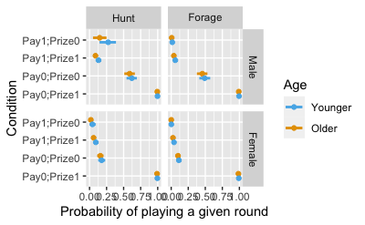

```r
FigFull <- ps_CrGtrSrA %>%
  pivot_longer(
    cols = everything(),
    names_to = "Condition",
    values_to = "Estimate"
  )  %>%
  separate(Condition, c("Pay", "Prize", "Age", "Game", "Gender"), sep = "_") %>%
  unite(c("Pay","Prize"), col = "Condition", sep = ";") %>%
  group_by(Condition, Age, Game, Gender) %>%
  mean_hdci(Estimate,.width = .9) %>%
  mutate(Gender = factor(Gender, levels = c("Male", "Female"))
         ,Game = factor(Game, levels = c("Hunt", "Forage"))
         ,Condition = factor(Condition, levels = c("Pay0;Prize1", "Pay0;Prize0",  "Pay1;Prize1", "Pay1;Prize0"))
         ,Age = factor(Age, levels = c("Younger", "Older"))) %>%
  ggplot(aes(x = Estimate, y = Condition, color = Age)) + scale_color_manual(values=c("#56B4E9", "#E69F00")) + geom_point(position = position_dodge(.5)) +
  geom_errorbar(aes(xmin = .lower, xmax = .upper), width=0, lwd = 1,  position = position_dodge(.5))  +
  facet_grid(Gender~Game, labeller = label_parsed) + xlab("Probability of playing a given round")

FigFull
```

We’ll save this figure for the paper.

```r
ggsave(
  plot = FigFull,
  file = "FigFull.pdf",
  path = "TablesAndFigures",
  width = 20,
  height = 10,
  units = "cm")
```

Now, let’s create a table of estimates on the probability scale.

```
`mutate_if()` ignored the following grouping variables:
Columns `Condition`, `Age`, `Game`
```

| Condition | Age | Game | p Male | 90%CI Male | p Female | 90%CI Female |
| --- | --- | --- | --- | --- | --- | --- |
| Pay1;Prize1 | Younger | Hunt | 0.13 | 0.09-0.17 | 0.09 | 0.06-0.12 |
| Pay1;Prize1 | Older | Hunt | 0.09 | 0.05-0.12 | 0.06 | 0.03-0.09 |
| Pay1;Prize1 | Younger | Forage | 0.06 | 0.03-0.09 | 0.04 | 0.02-0.06 |
| Pay1;Prize1 | Older | Forage | 0.04 | 0.02-0.06 | 0.03 | 0.01-0.04 |
| Pay1;Prize0 | Younger | Hunt | 0.27 | 0.15-0.39 | 0.04 | 0-0.09 |
| Pay1;Prize0 | Older | Hunt | 0.15 | 0.05-0.25 | 0.02 | 0-0.04 |
| Pay1;Prize0 | Younger | Forage | 0.02 | 0-0.04 | 0.00 | 0-0.01 |
| Pay1;Prize0 | Older | Forage | 0.01 | 0-0.02 | 0.00 | 0-0 |
| Pay0;Prize1 | Younger | Hunt | 1.00 | 0.99-1 | 0.99 | 0.99-1 |
| Pay0;Prize1 | Older | Hunt | 0.99 | 0.98-1 | 0.99 | 0.98-1 |

[output cut: 6 more lines]

And also save this for the paper.

```r
FullTableLaTeX <- TabCrGtrSrA %>%
  xtable(label = "Tab:FullModel",
         caption = "Mean posterior probabilities with 90 percent confidence intervals of playing any round by game type, pay/prize condition, age and gender."
         )

print(
  FullTableLaTeX,
    #only.contents = getOption("xtable.only.contents", T),
    sanitize.colnames.function = getOption("xtable.sanitize.colnames.function", NULL),
    include.rownames = FALSE,
    include.colnames = T,
       #hline.after = 3,
    caption.placement = "bottom",
    #size = "small",
    file = "TablesAndFigures/FullEstimates.txt",
)
```

## Contrasts

And now, let’s generate some category specific contrasts. First we’ll tabulate the absolute probability differences between the hunting and the gathering game.

```r
GameContrasts <- ps_CrGtrSrA %>%
  mutate(
     Pay1_Prize1_Younger_Female_GameContrast = Pay1_Prize1_Younger_Hunt_Female - Pay1_Prize1_Younger_Forage_Female
    ,Pay1_Prize0_Younger_Female_GameContrast = Pay1_Prize0_Younger_Hunt_Female - Pay1_Prize0_Younger_Forage_Female
    ,Pay0_Prize1_Younger_Female_GameContrast = Pay0_Prize1_Younger_Hunt_Female - Pay0_Prize1_Younger_Forage_Female
    ,Pay0_Prize0_Younger_Female_GameContrast = Pay0_Prize0_Younger_Hunt_Female - Pay0_Prize0_Younger_Forage_Female
    ,Pay1_Prize1_Younger_Male_GameContrast = Pay1_Prize1_Younger_Hunt_Male - Pay1_Prize1_Younger_Forage_Male
    ,Pay1_Prize0_Younger_Male_GameContrast = Pay1_Prize0_Younger_Hunt_Male - Pay1_Prize0_Younger_Forage_Male
    ,Pay0_Prize1_Younger_Male_GameContrast = Pay0_Prize1_Younger_Hunt_Male - Pay0_Prize1_Younger_Forage_Male
    ,Pay0_Prize0_Younger_Male_GameContrast = Pay0_Prize0_Younger_Hunt_Male - Pay0_Prize0_Younger_Forage_Male
    ,Pay1_Prize1_Older_Female_GameContrast = Pay1_Prize1_Older_Hunt_Female - Pay1_Prize1_Older_Forage_Female
    ,Pay1_Prize0_Older_Female_GameContrast = Pay1_Prize0_Older_Hunt_Female - Pay1_Prize0_Older_Forage_Female
    ,Pay0_Prize1_Older_Female_GameContrast = Pay0_Prize1_Older_Hunt_Female - Pay0_Prize1_Older_Forage_Female
    ,Pay0_Prize0_Older_Female_GameContrast = Pay0_Prize0_Older_Hunt_Female - Pay0_Prize0_Older_Forage_Female
    ,Pay1_Prize1_Older_Male_GameContrast = Pay1_Prize1_Older_Hunt_Male - Pay1_Prize1_Older_Forage_Male
    ,Pay1_Prize0_Older_Male_GameContrast = Pay1_Prize0_Older_Hunt_Male - Pay1_Prize0_Older_Forage_Male
    ,Pay0_Prize1_Older_Male_GameContrast = Pay0_Prize1_Older_Hunt_Male - Pay0_Prize1_Older_Forage_Male
    ,Pay0_Prize0_Older_Male_GameContrast = Pay0_Prize0_Older_Hunt_Male - Pay0_Prize0_Older_Forage_Male
    ) %>%
    select(ends_with("GameContrast")) %>%
    pivot_longer(
    cols = everything(),
    names_to = "Contrasts",
    values_to = "Estimate"
    )

GameContrasts  %>%
    group_by(Contrasts) %>%
    mean_hdci(Estimate,.width = .9) %>%
    mutate_if(is_double, round, 2)
```

| Contrasts | Estimate | .lower | .upper | .width | .point | .interval |
| --- | --- | --- | --- | --- | --- | --- |
| Pay0_Prize0_Older_Female_GameContrast | 0.06 | 0.02 | 0.10 | 0.9 | mean | hdci |
| Pay0_Prize0_Older_Male_GameContrast | 0.13 | 0.04 | 0.22 | 0.9 | mean | hdci |
| Pay0_Prize0_Younger_Female_GameContrast | 0.06 | 0.02 | 0.11 | 0.9 | mean | hdci |
| Pay0_Prize0_Younger_Male_GameContrast | 0.13 | 0.04 | 0.22 | 0.9 | mean | hdci |
| Pay0_Prize1_Older_Female_GameContrast | 0.00 | -0.01 | 0.03 | 0.9 | mean | hdci |
| Pay0_Prize1_Older_Male_GameContrast | 0.00 | -0.01 | 0.02 | 0.9 | mean | hdci |
| Pay0_Prize1_Younger_Female_GameContrast | 0.00 | -0.01 | 0.02 | 0.9 | mean | hdci |
| Pay0_Prize1_Younger_Male_GameContrast | 0.00 | -0.01 | 0.01 | 0.9 | mean | hdci |
| Pay1_Prize0_Older_Female_GameContrast | 0.02 | 0.00 | 0.04 | 0.9 | mean | hdci |
| Pay1_Prize0_Older_Male_GameContrast | 0.14 | 0.04 | 0.24 | 0.9 | mean | hdci |

[output cut: 6 more lines]

We can see that the Pay0;Prize1 conditions are outliers here. What is the mean probability overall increase moving from the foraging game to the hunting game excluding our Pay0;Prize1 conditions?

```r
  GameContrasts  %>%
    filter(!grepl("Pay0_Prize1",Contrasts)) %>%
    mean_hdci(Estimate,.width = .9) %>%
    mutate_if(is_double, round, 2)
```

| Estimate | .lower | .upper | .width | .point | .interval |
| --- | --- | --- | --- | --- | --- |
| 0.09 | 0 | 0.2 | 0.9 | mean | hdci |

And ridgeplots:

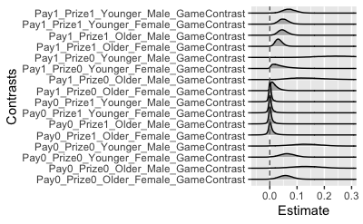

Next, we’ll explore the differences per category between the paid and non-paid conditions.

```r
PayContrasts <- ps_CrGtrSrA %>%
  mutate(
       Prize1_Younger_Forage_Female_PayContrast = Pay0_Prize1_Younger_Forage_Female - Pay1_Prize1_Younger_Forage_Female
      ,Prize0_Younger_Forage_Female_PayContrast = Pay0_Prize0_Younger_Forage_Female - Pay1_Prize0_Younger_Forage_Female
      ,Prize1_Younger_Hunt_Female_PayContrast = Pay0_Prize1_Younger_Hunt_Female - Pay1_Prize1_Younger_Hunt_Female
      ,Prize0_Younger_Hunt_Female_PayContrast = Pay0_Prize0_Younger_Hunt_Female - Pay1_Prize0_Younger_Hunt_Female
      ,Prize1_Younger_Forage_Male_PayContrast = Pay0_Prize1_Younger_Forage_Male - Pay1_Prize1_Younger_Forage_Male
      ,Prize0_Younger_Forage_Male_PayContrast = Pay0_Prize0_Younger_Forage_Male - Pay1_Prize0_Younger_Forage_Male
      ,Prize1_Younger_Hunt_Male_PayContrast = Pay0_Prize1_Younger_Hunt_Male - Pay1_Prize1_Younger_Hunt_Male
      ,Prize0_Younger_Hunt_Male_PayContrast = Pay0_Prize0_Younger_Hunt_Male - Pay1_Prize0_Younger_Hunt_Male
      ,Prize1_Older_Forage_Female_PayContrast = Pay0_Prize1_Older_Forage_Female - Pay1_Prize1_Older_Forage_Female
      ,Prize0_Older_Forage_Female_PayContrast = Pay0_Prize0_Older_Forage_Female - Pay1_Prize0_Older_Forage_Female
      ,Prize1_Older_Hunt_Female_PayContrast = Pay0_Prize1_Older_Hunt_Female - Pay1_Prize1_Older_Hunt_Female
      ,Prize0_Older_Hunt_Female_PayContrast = Pay0_Prize0_Older_Hunt_Female - Pay1_Prize0_Older_Hunt_Female
      ,Prize1_Older_Forage_Male_PayContrast = Pay0_Prize1_Older_Forage_Male - Pay1_Prize1_Older_Forage_Male
      ,Prize0_Older_Forage_Male_PayContrast = Pay0_Prize0_Older_Forage_Male - Pay1_Prize0_Older_Forage_Male
      ,Prize1_Older_Hunt_Male_PayContrast = Pay0_Prize1_Older_Hunt_Male - Pay1_Prize1_Older_Hunt_Male
      ,Prize0_Older_Hunt_Male_PayContrast = Pay0_Prize0_Older_Hunt_Male - Pay1_Prize0_Older_Hunt_Male
    ) %>%
    select(ends_with("PayContrast")) %>%
    pivot_longer(
    cols = everything(),
    names_to = "Contrasts",
    values_to = "Estimate"
    )

PayContrasts  %>%
    group_by(Contrasts) %>%
    mean_hdci(Estimate,.width = .9) %>%
    mutate_if(is_double, round, 2)
```

| Contrasts | Estimate | .lower | .upper | .width | .point | .interval |
| --- | --- | --- | --- | --- | --- | --- |
| Prize0_Older_Forage_Female_PayContrast | 0.10 | 0.06 | 0.13 | 0.9 | mean | hdci |
| Prize0_Older_Forage_Male_PayContrast | 0.45 | 0.37 | 0.53 | 0.9 | mean | hdci |
| Prize0_Older_Hunt_Female_PayContrast | 0.14 | 0.09 | 0.19 | 0.9 | mean | hdci |
| Prize0_Older_Hunt_Male_PayContrast | 0.44 | 0.31 | 0.56 | 0.9 | mean | hdci |
| Prize0_Younger_Forage_Female_PayContrast | 0.11 | 0.07 | 0.15 | 0.9 | mean | hdci |
| Prize0_Younger_Forage_Male_PayContrast | 0.48 | 0.39 | 0.56 | 0.9 | mean | hdci |
| Prize0_Younger_Hunt_Female_PayContrast | 0.14 | 0.06 | 0.21 | 0.9 | mean | hdci |
| Prize0_Younger_Hunt_Male_PayContrast | 0.35 | 0.20 | 0.49 | 0.9 | mean | hdci |
| Prize1_Older_Forage_Female_PayContrast | 0.96 | 0.94 | 0.98 | 0.9 | mean | hdci |
| Prize1_Older_Forage_Male_PayContrast | 0.95 | 0.93 | 0.98 | 0.9 | mean | hdci |

[output cut: 6 more lines]

Let’s visualise with some some helpful ridgeplots.

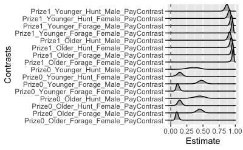

```r
PayContrasts  %>%
  ggplot(aes(x = Estimate, y = Contrasts)) + geom_density_ridges() + coord_cartesian(xlim = c(-0, 1)) + geom_vline(xintercept=0, linetype="dashed", color = "#696969", size=.5)
```

Next the differences between the prize, no-prize conditions:

```r
PrizeContrasts <- ps_CrGtrSrA %>%
  mutate(
         Pay1_Younger_Forage_Female_PrizeContrast = Pay1_Prize1_Younger_Forage_Female - Pay1_Prize0_Younger_Forage_Female
        ,Pay0_Younger_Forage_Female_PrizeContrast = Pay0_Prize1_Younger_Forage_Female - Pay0_Prize0_Younger_Forage_Female
        ,Pay1_Younger_Hunt_Female_PrizeContrast = Pay1_Prize1_Younger_Hunt_Female - Pay1_Prize0_Younger_Hunt_Female
        ,Pay0_Younger_Hunt_Female_PrizeContrast = Pay0_Prize1_Younger_Hunt_Female - Pay0_Prize0_Younger_Hunt_Female
        ,Pay1_Younger_Forage_Male_PrizeContrast = Pay1_Prize1_Younger_Forage_Male - Pay1_Prize0_Younger_Forage_Male
        ,Pay0_Younger_Forage_Male_PrizeContrast = Pay0_Prize1_Younger_Forage_Male - Pay0_Prize0_Younger_Forage_Male
        ,Pay1_Younger_Hunt_Male_PrizeContrast = Pay1_Prize1_Younger_Hunt_Male - Pay1_Prize0_Younger_Hunt_Male
        ,Pay0_Younger_Hunt_Male_PrizeContrast = Pay0_Prize1_Younger_Hunt_Male - Pay0_Prize0_Younger_Hunt_Male
        ,Pay1_Older_Forage_Female_PrizeContrast = Pay1_Prize1_Older_Forage_Female - Pay1_Prize0_Older_Forage_Female
        ,Pay0_Older_Forage_Female_PrizeContrast = Pay0_Prize1_Older_Forage_Female - Pay0_Prize0_Older_Forage_Female
        ,Pay1_Older_Hunt_Female_PrizeContrast = Pay1_Prize1_Older_Hunt_Female - Pay1_Prize0_Older_Hunt_Female
        ,Pay0_Older_Hunt_Female_PrizeContrast = Pay0_Prize1_Older_Hunt_Female - Pay0_Prize0_Older_Hunt_Female
        ,Pay1_Older_Forage_Male_PrizeContrast = Pay1_Prize1_Older_Forage_Male - Pay1_Prize0_Older_Forage_Male
        ,Pay0_Older_Forage_Male_PrizeContrast = Pay0_Prize1_Older_Forage_Male - Pay0_Prize0_Older_Forage_Male
        ,Pay1_Older_Hunt_Male_PrizeContrast = Pay1_Prize1_Older_Hunt_Male - Pay1_Prize0_Older_Hunt_Male
        ,Pay0_Older_Hunt_Male_PrizeContrast = Pay0_Prize1_Older_Hunt_Male - Pay0_Prize0_Older_Hunt_Male
    ) %>%
    select(ends_with("PrizeContrast")) %>%
    pivot_longer(
    cols = everything(),
    names_to = "Contrasts",
    values_to = "Estimate"
    )

PrizeContrasts  %>%
    group_by(Contrasts) %>%
    mean_hdci(Estimate,.width = .9) %>%
    mutate_if(is_double, round, 2)
```

| Contrasts | Estimate | .lower | .upper | .width | .point | .interval |
| --- | --- | --- | --- | --- | --- | --- |
| Pay0_Older_Forage_Female_PrizeContrast | 0.89 | 0.85 | 0.93 | 0.9 | mean | hdci |
| Pay0_Older_Forage_Male_PrizeContrast | 0.53 | 0.46 | 0.62 | 0.9 | mean | hdci |
| Pay0_Older_Hunt_Female_PrizeContrast | 0.83 | 0.78 | 0.88 | 0.9 | mean | hdci |
| Pay0_Older_Hunt_Male_PrizeContrast | 0.41 | 0.33 | 0.49 | 0.9 | mean | hdci |
| Pay0_Younger_Forage_Female_PrizeContrast | 0.88 | 0.84 | 0.92 | 0.9 | mean | hdci |
| Pay0_Younger_Forage_Male_PrizeContrast | 0.50 | 0.42 | 0.58 | 0.9 | mean | hdci |
| Pay0_Younger_Hunt_Female_PrizeContrast | 0.82 | 0.76 | 0.87 | 0.9 | mean | hdci |
| Pay0_Younger_Hunt_Male_PrizeContrast | 0.38 | 0.30 | 0.45 | 0.9 | mean | hdci |
| Pay1_Older_Forage_Female_PrizeContrast | 0.03 | 0.01 | 0.04 | 0.9 | mean | hdci |
| Pay1_Older_Forage_Male_PrizeContrast | 0.03 | 0.01 | 0.06 | 0.9 | mean | hdci |

[output cut: 6 more lines]

Once again, let’s see those ridge-plots!

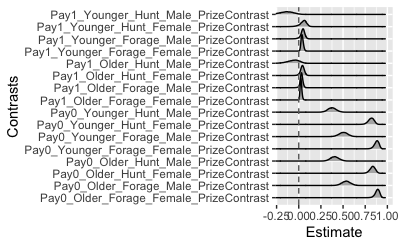

```r
PrizeContrasts  %>%
  ggplot(aes(x = Estimate, y = Contrasts)) + geom_density_ridges() + coord_cartesian(xlim = c(-0.2, 1)) + geom_vline(xintercept=0, linetype="dashed", color = "#696969", size=.5)
```

Now, the difference between genders

```r
GenderContrasts <- ps_CrGtrSrA %>%
  mutate(
     Pay1_Prize1_Younger_Forage_GenderContrast = Pay1_Prize1_Younger_Forage_Male - Pay1_Prize1_Younger_Forage_Female
    ,Pay1_Prize0_Younger_Forage_GenderContrast = Pay1_Prize0_Younger_Forage_Male - Pay1_Prize0_Younger_Forage_Female
    ,Pay0_Prize1_Younger_Forage_GenderContrast = Pay0_Prize1_Younger_Forage_Male - Pay0_Prize1_Younger_Forage_Female
    ,Pay0_Prize0_Younger_Forage_GenderContrast = Pay0_Prize0_Younger_Forage_Male - Pay0_Prize0_Younger_Forage_Female
    ,Pay1_Prize1_Younger_Hunt_GenderContrast = Pay1_Prize1_Younger_Hunt_Male - Pay1_Prize1_Younger_Hunt_Female
    ,Pay1_Prize0_Younger_Hunt_GenderContrast = Pay1_Prize0_Younger_Hunt_Male - Pay1_Prize0_Younger_Hunt_Female
    ,Pay0_Prize1_Younger_Hunt_GenderContrast = Pay0_Prize1_Younger_Hunt_Male - Pay0_Prize1_Younger_Hunt_Female
    ,Pay0_Prize0_Younger_Hunt_GenderContrast = Pay0_Prize0_Younger_Hunt_Male - Pay0_Prize0_Younger_Hunt_Female
    ,Pay1_Prize1_Older_Forage_GenderContrast = Pay1_Prize1_Older_Forage_Male - Pay1_Prize1_Older_Forage_Female
    ,Pay1_Prize0_Older_Forage_GenderContrast = Pay1_Prize0_Older_Forage_Male - Pay1_Prize0_Older_Forage_Female
    ,Pay0_Prize1_Older_Forage_GenderContrast = Pay0_Prize1_Older_Forage_Male - Pay0_Prize1_Older_Forage_Female
    ,Pay0_Prize0_Older_Forage_GenderContrast = Pay0_Prize0_Older_Forage_Male - Pay0_Prize0_Older_Forage_Female
    ,Pay1_Prize1_Older_Hunt_GenderContrast = Pay1_Prize1_Older_Hunt_Male - Pay1_Prize1_Older_Hunt_Female
    ,Pay1_Prize0_Older_Hunt_GenderContrast = Pay1_Prize0_Older_Hunt_Male - Pay1_Prize0_Older_Hunt_Female
    ,Pay0_Prize1_Older_Hunt_GenderContrast = Pay0_Prize1_Older_Hunt_Male - Pay0_Prize1_Older_Hunt_Female
    ,Pay0_Prize0_Older_Hunt_GenderContrast = Pay0_Prize0_Older_Hunt_Male - Pay0_Prize0_Older_Hunt_Female
) %>%
  select(ends_with("GenderContrast")) %>%
    pivot_longer(
    cols = everything(),
    names_to = "Contrasts",
    values_to = "Estimate"
  )

GenderContrasts  %>%
    group_by(Contrasts) %>%
    mean_hdci(Estimate,.width = .9) %>%
    mutate_if(is_double, round, 2)
```

| Contrasts | Estimate | .lower | .upper | .width | .point | .interval |
| --- | --- | --- | --- | --- | --- | --- |
| Pay0_Prize0_Older_Forage_GenderContrast | 0.36 | 0.29 | 0.43 | 0.9 | mean | hdci |
| Pay0_Prize0_Older_Hunt_GenderContrast | 0.43 | 0.36 | 0.50 | 0.9 | mean | hdci |
| Pay0_Prize0_Younger_Forage_GenderContrast | 0.38 | 0.31 | 0.45 | 0.9 | mean | hdci |
| Pay0_Prize0_Younger_Hunt_GenderContrast | 0.44 | 0.37 | 0.51 | 0.9 | mean | hdci |
| Pay0_Prize1_Older_Forage_GenderContrast | 0.01 | -0.01 | 0.03 | 0.9 | mean | hdci |
| Pay0_Prize1_Older_Hunt_GenderContrast | 0.00 | -0.01 | 0.02 | 0.9 | mean | hdci |
| Pay0_Prize1_Younger_Forage_GenderContrast | 0.00 | -0.01 | 0.02 | 0.9 | mean | hdci |
| Pay0_Prize1_Younger_Hunt_GenderContrast | 0.00 | -0.01 | 0.01 | 0.9 | mean | hdci |
| Pay1_Prize0_Older_Forage_GenderContrast | 0.01 | 0.00 | 0.02 | 0.9 | mean | hdci |
| Pay1_Prize0_Older_Hunt_GenderContrast | 0.13 | 0.03 | 0.22 | 0.9 | mean | hdci |

[output cut: 6 more lines]

Now with ridgeplots!

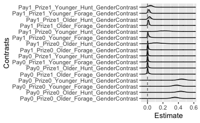

```r
GenderContrasts  %>%
  ggplot(aes(x = Estimate, y = Contrasts)) + geom_density_ridges() + coord_cartesian(xlim = c(-0.05, .6)) + geom_vline(xintercept=0, linetype="dashed", color = "#696969", size=.5)
```

Let’s take the averages for some specific contrasts. First, let’s look at the average for the pay condition contrasts for the hunting game:

```r
  GenderContrasts  %>%
    filter(grepl("Pay1",Contrasts)) %>%
    filter(grepl("Hunt",Contrasts)) %>%
    mean_hdci(Estimate,.width = .9) %>%
    mutate_if(is_double, round, 2)
```

| Estimate | .lower | .upper | .width | .point | .interval |
| --- | --- | --- | --- | --- | --- |
| 0.11 | -0.01 | 0.26 | 0.9 | mean | hdci |

And the averages absolute probability increase for the pay0 prize0 contrast:

```r
  GenderContrasts  %>%
    filter(grepl("Pay0_Prize0",Contrasts)) %>%
    mean_hdci(Estimate,.width = .9) %>%
    mutate_if(is_double, round, 2)
```

| Estimate | .lower | .upper | .width | .point | .interval |
| --- | --- | --- | --- | --- | --- |
| 0.4 | 0.31 | 0.49 | 0.9 | mean | hdci |

And finally the younger-older age contrasts:

```r
AgeContrasts <- ps_CrGtrSrA %>%
  mutate(
         Pay1_Prize1_Forage_Female_AgeContrast = Pay1_Prize1_Younger_Forage_Female - Pay1_Prize1_Older_Forage_Female
        ,Pay1_Prize0_Forage_Female_AgeContrast = Pay1_Prize0_Younger_Forage_Female - Pay1_Prize0_Older_Forage_Female
        ,Pay0_Prize1_Forage_Female_AgeContrast = Pay0_Prize1_Younger_Forage_Female - Pay0_Prize1_Older_Forage_Female
        ,Pay0_Prize0_Forage_Female_AgeContrast = Pay0_Prize0_Younger_Forage_Female - Pay0_Prize0_Older_Forage_Female
        ,Pay1_Prize1_Hunt_Female_AgeContrast = Pay1_Prize1_Younger_Hunt_Female - Pay1_Prize1_Older_Hunt_Female
        ,Pay1_Prize0_Hunt_Female_AgeContrast = Pay1_Prize0_Younger_Hunt_Female - Pay1_Prize0_Older_Hunt_Female
        ,Pay0_Prize1_Hunt_Female_AgeContrast = Pay0_Prize1_Younger_Hunt_Female - Pay0_Prize1_Older_Hunt_Female
        ,Pay0_Prize0_Hunt_Female_AgeContrast = Pay0_Prize0_Younger_Hunt_Female - Pay0_Prize0_Older_Hunt_Female
        ,Pay1_Prize1_Forage_Male_AgeContrast = Pay1_Prize1_Younger_Forage_Male - Pay1_Prize1_Older_Forage_Male
        ,Pay1_Prize0_Forage_Male_AgeContrast = Pay1_Prize0_Younger_Forage_Male - Pay1_Prize0_Older_Forage_Male
        ,Pay0_Prize1_Forage_Male_AgeContrast = Pay0_Prize1_Younger_Forage_Male - Pay0_Prize1_Older_Forage_Male
        ,Pay0_Prize0_Forage_Male_AgeContrast = Pay0_Prize0_Younger_Forage_Male - Pay0_Prize0_Older_Forage_Male
        ,Pay1_Prize1_Hunt_Male_AgeContrast = Pay1_Prize1_Younger_Hunt_Male - Pay1_Prize1_Older_Hunt_Male
        ,Pay1_Prize0_Hunt_Male_AgeContrast = Pay1_Prize0_Younger_Hunt_Male - Pay1_Prize0_Older_Hunt_Male
        ,Pay0_Prize1_Hunt_Male_AgeContrast = Pay0_Prize1_Younger_Hunt_Male - Pay0_Prize1_Older_Hunt_Male
        ,Pay0_Prize0_Hunt_Male_AgeContrast = Pay0_Prize0_Younger_Hunt_Male - Pay0_Prize0_Older_Hunt_Male
    ) %>%
    select(ends_with("AgeContrast")) %>%
    pivot_longer(
    cols = everything(),
    names_to = "Contrasts",
    values_to = "Estimate"
    )

AgeContrasts  %>%
    group_by(Contrasts) %>%
    mean_hdci(Estimate,.width = .9) %>%
    mutate_if(is_double, round, 2) %>%
    arrange(desc(.lower, Estimate))
```

| Contrasts | Estimate | .lower | .upper | .width | .point | .interval |
| --- | --- | --- | --- | --- | --- | --- |
| Pay0_Prize1_Hunt_Male_AgeContrast | 0.00 | 0.00 | 0.01 | 0.9 | mean | hdci |
| Pay1_Prize0_Forage_Female_AgeContrast | 0.00 | 0.00 | 0.00 | 0.9 | mean | hdci |
| Pay1_Prize0_Forage_Male_AgeContrast | 0.01 | 0.00 | 0.02 | 0.9 | mean | hdci |
| Pay1_Prize1_Forage_Female_AgeContrast | 0.01 | 0.00 | 0.03 | 0.9 | mean | hdci |
| Pay1_Prize1_Forage_Male_AgeContrast | 0.02 | 0.00 | 0.04 | 0.9 | mean | hdci |
| Pay1_Prize1_Hunt_Female_AgeContrast | 0.03 | 0.00 | 0.06 | 0.9 | mean | hdci |
| Pay1_Prize1_Hunt_Male_AgeContrast | 0.04 | 0.00 | 0.09 | 0.9 | mean | hdci |
| Pay0_Prize0_Forage_Female_AgeContrast | 0.01 | -0.01 | 0.04 | 0.9 | mean | hdci |
| Pay0_Prize1_Forage_Female_AgeContrast | 0.01 | -0.01 | 0.03 | 0.9 | mean | hdci |
| Pay0_Prize1_Forage_Male_AgeContrast | 0.00 | -0.01 | 0.02 | 0.9 | mean | hdci |

[output cut: 6 more lines]

```r
NA
NA
NA
```

Finally, the final ridgeplots.

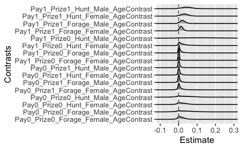

```r
AgeContrasts  %>%
  ggplot(aes(x = Estimate, y = Contrasts)) + geom_density_ridges() + coord_cartesian(xlim = c(-0.1, .3)) + geom_vline(xintercept=0, linetype="dashed", color = "#696969", size=.5)
```

### Final Figures

Last but not least we’ll put all these contrasts together into presentable figures. Let’s start with a little data wrangling.

```r
GameContrasts %<>% mutate(ContrastType = "Game Contrasts")
PayContrasts %<>% mutate(ContrastType = "Pay Contrasts")
PrizeContrasts %<>% mutate(ContrastType = "Prize Contrasts")
GenderContrasts %<>% mutate(ContrastType = "Gender Contrasts")
AgeContrasts %<>% mutate(ContrastType = "Age Contrasts")

AllContrasts <- rbind(GameContrasts, PrizeContrasts, PayContrasts, GenderContrasts, AgeContrasts) %>%
  separate(Contrasts, c("A", "B", "C", "D", "E"), sep = "_") %>%
  unite(c("A", "B", "C", "D"), col = "Contrasts", sep = ";")
```

Now let’s add a splash of colour to our axis labels.

```r
AllContrasts %<>%
  mutate_if(is.character,
      str_replace_all, pattern = "Hunt", replacement = "<b style='color:#e99636'>Hunt</b>") %>%
  mutate_if(is.character,
      str_replace_all, pattern = "Forage", replacement = "<b style='color:#3c5c33'>Forage</b>") %>%
    mutate_if(is.character,
      str_replace_all, pattern = "Younger", replacement = "<b style='color:#61b8eb'>Younger</b>") %>%
    mutate_if(is.character,
      str_replace_all, pattern = "Older", replacement = "<b style='color:#e2a51e'>Older</b>") %>%
    mutate_if(is.character,
      str_replace_all, pattern = "Male", replacement = "<b style='color:#0000FF'>Male</b>") %>%
    mutate_if(is.character,
      str_replace_all, pattern = "Female", replacement = "<b style='color:#f4746c'>Female</b>") %>%
    mutate_if(is.character,
      str_replace_all, pattern = "Prize0", replacement = "<b style='color:#FF0000'>No Prize</b>") %>%
    mutate_if(is.character,
      str_replace_all, pattern = "Prize1", replacement = "<b style='color:#7d5791'>Prizes</b>") %>%
    mutate_if(is.character,
      str_replace_all, pattern = "Pay0", replacement = "<b style='color:#fbcc04'>Free</b>") %>%
    mutate_if(is.character,
      str_replace_all, pattern = "Pay1", replacement = "<b style='color:#660000'>Costly</b>")
```

Now let’s look at all of them together.

[figure not shown]

```r
ContrastTable <- AllContrasts %>%
  group_by(Contrasts, ContrastType) %>%
  mean_hdci(Estimate,.width = .9) %>%
  ggplot(aes(x = Estimate, y = Contrasts))  + geom_point() +
  geom_errorbar(aes(xmin = .lower, xmax = .upper), width=0, lwd = 1)  +
  facet_grid(rows = vars(ContrastType), scales = "free") + xlab("Absolute difference in per-round play probability") +  coord_cartesian(xlim = c(-0.25, 1)) + geom_vline(xintercept=0, linetype="dashed", color = "#696969", size=.5) +
  theme(axis.text.y = element_markdown())

ContrastTable

ggsave(
  plot = ContrastTable,
  file = "ContrastTable.pdf",
  path = "TablesAndFigures",
  width = 21,
  height = 30,
  units = "cm")
```

This figure contains everything, which is perhaps too much information. So let’s chop this up into more managable chunks. First, we’ll seperate the pay and prize contrasts (i.e., What we’ve called ‘condition’ in the paper’).

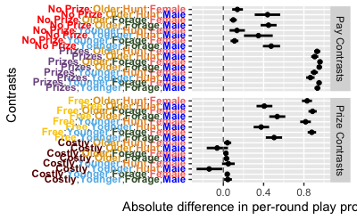

```r
ContrastTableCondition <- AllContrasts %>%
  filter(ContrastType == "Prize Contrasts" | ContrastType == "Pay Contrasts") %>%
  group_by(Contrasts, ContrastType) %>%
  mean_hdci(Estimate,.width = .9) %>%
  ggplot(aes(x = Estimate, y = Contrasts))  + geom_point() +
  geom_errorbar(aes(xmin = .lower, xmax = .upper), width=0, lwd = 1)  +
  facet_grid(rows = vars(ContrastType), scales = "free") + xlab("Absolute difference in per-round play probability") +  coord_cartesian(xlim = c(-0.25, 1)) + geom_vline(xintercept=0, linetype="dashed", color = "#696969", size=.5) +
  theme(axis.text.y = element_markdown())

ContrastTableCondition

ggsave(
  plot = ContrastTableCondition,
  file = "ContrastTableCondition.pdf",
  path = "TablesAndFigures",
  width = 21,
  height = 15,
  units = "cm")
```

That’s slightly easier to follow. Let’s do a couple more, first just hunting versus gathering game.

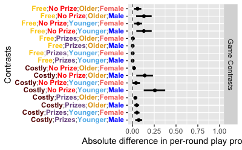

```r
ContrastTableGame <- AllContrasts %>%
  filter(ContrastType == "Game Contrasts") %>%
  group_by(Contrasts, ContrastType) %>%
  mean_hdci(Estimate,.width = .9) %>%
  ggplot(aes(x = Estimate, y = Contrasts))  + geom_point() +
  geom_errorbar(aes(xmin = .lower, xmax = .upper), width=0, lwd = 1)  +
  facet_grid(rows = vars(ContrastType), scales = "free") + xlab("Absolute difference in per-round play probability") +  coord_cartesian(xlim = c(0, 1)) + geom_vline(xintercept=0, linetype="dashed", color = "#696969", size=.5) +
  theme(axis.text.y = element_markdown())

ContrastTableGame

ggsave(
  plot = ContrastTableGame,
  file = "ContrastTableGame.pdf",
  path = "TablesAndFigures",
  width = 21,
  height = 10,
  units = "cm")
```

```r
NA
NA
NA
```

Last but not least we’ll put the age and gender contrasts together.

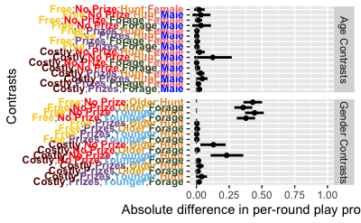

```r
ContrastTableAgeGender <- AllContrasts %>%
  filter(ContrastType == "Gender Contrasts" | ContrastType == "Age Contrasts") %>%
  group_by(Contrasts, ContrastType) %>%
  mean_hdci(Estimate,.width = .9) %>%
  ggplot(aes(x = Estimate, y = Contrasts))  + geom_point() +
  geom_errorbar(aes(xmin = .lower, xmax = .upper), width=0, lwd = 1)  +
  facet_grid(rows = vars(ContrastType), scales = "free") + xlab("Absolute difference in per-round play probability") +  coord_cartesian(xlim = c(0, 1)) + geom_vline(xintercept=0, linetype="dashed", color = "#696969", size=.5) +
  theme(axis.text.y = element_markdown())

ContrastTableAgeGender


ggsave(
  plot = ContrastTableAgeGender,
  file = "ContrastTableAgeGender.pdf",
  path = "TablesAndFigures",
  width = 21,
  height = 15,
  units = "cm")
```